# Chapter 12: Tidy data

```r
library(tidyverse)
```

# 12.2 Tidy data

## 12.2.1 Exercises

1. Using prose, describe how the variables and observations are organised in each of the sample tables.

**`table2`: The `type` column indicates whether each row of data contains an observation of the number of cases or the population. This then means that the values for `country` and `year` are duplicated across two rows - each observation is split across those two rows.**

**`table3`: The `rate` column in this case is a string that contains two separate values - `cases` and `population`. Attempting to perform any computation or aggregation with the data in this format would need this string to be broken into separate numeric variables first.**

**`table4`: There are two separate tables, one for the `cases` variable and the other for `population`. Within each table the rows correspond to a country and the columns then contain separate observations on the target variable for each given year. This means that there are multiple observations within each row, yet the observations within each table are incomplete.**

2. Compute the rate for `table2`, and `table4a` + `table4b`. You will need to perform four operations:
3. Extract the number of TB cases per country per year.
4. Extract the matching population per country per year.
5. Divide cases by population, and multiply by 10000.
6. Store back in the appropriate place.

```r
t2cases <- table2 %>%
  filter(type == "cases") %>%
  select(country, year, cases = count)
t2pop <- table2 %>%
  filter(type == "population") %>%
  select(country, year, pop = count)
t2rate <- t2cases %>%
  left_join(t2pop, by = c("country", "year")) %>%
  mutate(rate = (cases / pop) * 10000)
t2rate
```

| country | year | cases | pop | rate |
| --- | --- | --- | --- | --- |
| Afghanistan | 1999 | 745 | 19987071 | 0.372741 |
| Afghanistan | 2000 | 2666 | 20595360 | 1.294466 |
| Brazil | 1999 | 37737 | 172006362 | 2.193930 |
| Brazil | 2000 | 80488 | 174504898 | 4.612363 |
| China | 1999 | 212258 | 1272915272 | 1.667495 |
| China | 2000 | 213766 | 1280428583 | 1.669488 |

```r
t4rate <- table4a %>%
  left_join(table4b, by = c("country"), suffix = c("cases", "pop")) %>%
  mutate(
    `1999rate` = (`1999cases` / `1999pop`) * 10000,
    `2000rate` = (`2000cases` / `2000pop`) * 10000
  )
t4rate
```

| country | 1999cases | 2000cases | 1999pop | 2000pop | 1999rate | 2000rate |
| --- | --- | --- | --- | --- | --- | --- |
| Afghanistan | 745 | 2666 | 19987071 | 20595360 | 0.372741 | 1.294466 |
| Brazil | 37737 | 80488 | 172006362 | 174504898 | 2.193930 | 4.612363 |
| China | 212258 | 213766 | 1272915272 | 1280428583 | 1.667495 | 1.669488 |

Which representation is easiest to work with? Which is hardest? Why?

**`table3` would be worst of all because it requires text processing. `table2` required some intermediate steps before putting things back together but results in a generally tidy format. `table4a` and `table4b` required some extra arguments to the join function for clarity and ends up putting the calculated rates into two separate columns so it remains untidy.**

3. Recreate the plot showing change in cases over time using `table2` instead of `table1`. What do you need to do first?

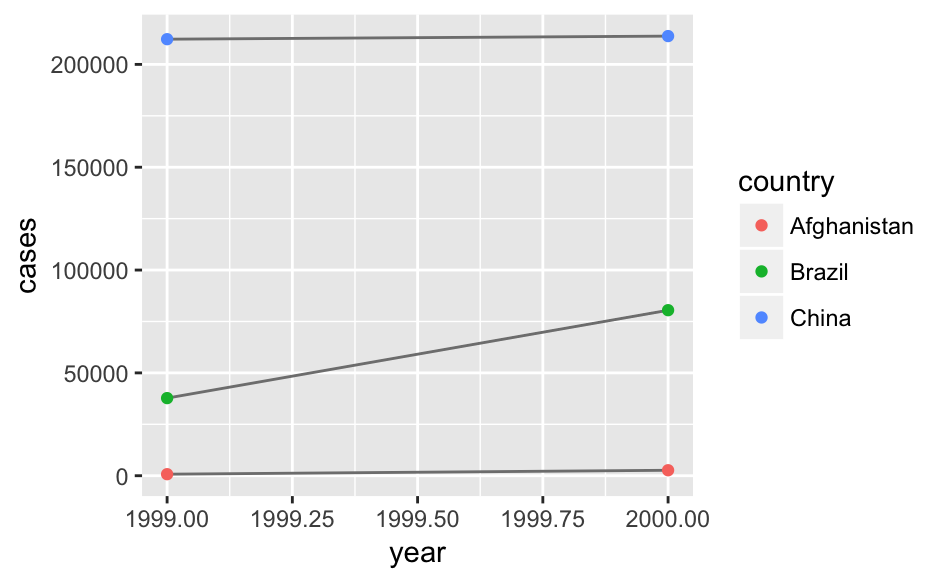

```r
library(ggplot2)
table2 %>%
  filter(type == "cases") %>%
  ggplot(aes(year, count)) +
    geom_line(aes(group = country), colour = "grey50") +
    geom_point(aes(colour = country)) +
    ylab("cases")
```

**I needed to filter the data to select only the rows that had numbers of cases, and then I also changed the label on the y-axis to correctly describe the variable.**

# 12.3 Spreading and gathering

## 12.3.3 Exercises

1. Why are `gather()` and `spread()` not perfectly symmetrical?

Carefully consider the following example:

```r
stocks <- tibble(
  year   = c(2015, 2015, 2016, 2016),
  half  = c(   1,    2,     1,    2),
  return = c(1.88, 0.59, 0.92, 0.17)
)
stocks %>%
  spread(year, return)  %>%
  gather("year", "return", `2015`:`2016`)
```

| half | year | return |
| --- | --- | --- |
| 1 | 2015 | 1.88 |
| 2 | 2015 | 0.59 |
| 1 | 2016 | 0.92 |
| 2 | 2016 | 0.17 |

(Hint: look at the variable types and think about column names.)

**`spread()` only needs two arguments because it determines the new column names from the values in the `key` column. All it needs to do is coerce those values to be strings so they can function as variable names. `gather()` needs to be told the new column names and then which existing variables are to be converted into those key-value columns.**

Both `spread()` and `gather()` have a convert argument. What does it do?

**If `convert = TRUE` is passed to either function then it will attempt to convert the new variables to an appropriate type. Note that `year` in the example code above has ended up as a string, because the `gather()` function had used the `2015` and `2016` variable names as strings. Running the same code with conversion will see it return to being a numeric variable, as shown below.**

```r
stocks <- tibble(
  year   = c(2015, 2015, 2016, 2016),
  half  = c(   1,    2,     1,    2),
  return = c(1.88, 0.59, 0.92, 0.17)
)
stocks %>%
  spread(year, return)  %>%
  gather("year", "return", `2015`:`2016`, convert = TRUE)
```

| half | year | return |
| --- | --- | --- |
| 1 | 2015 | 1.88 |
| 2 | 2015 | 0.59 |
| 1 | 2016 | 0.92 |
| 2 | 2016 | 0.17 |

2. Why does this code fail?

```r
table4a %>%
  gather(1999, 2000, key = "year", value = "cases")
```

```
Error: Position must be between 0 and n
```

**The existing variable names are non-syntactic so the arguments need to be surrounded by backticks - see below.**

```r
table4a %>%
  gather(`1999`, `2000`, key = "year", value = "cases")
```

| country | year | cases |
| --- | --- | --- |
| Afghanistan | 1999 | 745 |
| Brazil | 1999 | 37737 |
| China | 1999 | 212258 |
| Afghanistan | 2000 | 2666 |
| Brazil | 2000 | 80488 |
| China | 2000 | 213766 |

3. Why does spreading this tibble fail? How could you add a new column to fix the problem?

```r
people <- tribble(
  ~name,             ~key,    ~value,
  #-----------------|--------|------
  "Phillip Woods",   "age",       45,
  "Phillip Woods",   "height",   186,
  "Phillip Woods",   "age",       50,
  "Jessica Cordero", "age",       37,
  "Jessica Cordero", "height",   156
)
people %>%
  spread(key, value)
```

```
Error: Duplicate identifiers for rows (1, 3)
```

**The third row in the original dataset has the same name and key as the first row, i.e., the function runs into a situation where there are two possible values to go into the one cell for Phillip Woods’s age column. You could add a column that allows the tidying function to uniquely identify people who might have the same name, e.g., add an address or a unique ID number.**

4. Tidy the simple tibble below. Do you need to spread or gather it? What are the variables?

```r
preg <- tribble(
  ~pregnant, ~male, ~female,
  "yes",     NA,    10,
  "no",      20,    12
)
preg %>%
  gather("sex", "n", `male`:`female`)
```

| pregnant | sex | n |
| --- | --- | --- |
| yes | male | NA |
| no | male | 20 |
| yes | female | 10 |
| no | female | 12 |

# 12.4 Separating and uniting

## 12.4.3 Exercises

1. What do the `extra` and `fill` arguments do in `separate()`? Experiment with the various options for the following two toy datasets.

```r
?separate
```

**These two arguments allow us to specify what happens with any row(s) that has too many (`extra`) or too few (`fill`) pieces to fit the `into` variables. By default, warnings will be issued in both cases, but we can instead `drop` extra values or `merge` them into the final column, and we can specify whether missing values should be filled on the right (final column(s)) or left.**

```r
tibble(x = c("a,b,c", "d,e,f,g", "h,i,j")) %>%
  separate(x, c("one", "two", "three"))
```

```
Too many values at 1 locations: 2
```

|  | one | two | three |
| --- | --- | --- | --- |
| 1 | a | b | c |
| 2 | d | e | f |
| 3 | h | i | j |

```r
tibble(x = c("a,b,c", "d,e,f,g", "h,i,j")) %>%
  separate(x, c("one", "two", "three"), extra = "drop")
```

|  | one | two | three |
| --- | --- | --- | --- |
| 1 | a | b | c |
| 2 | d | e | f |
| 3 | h | i | j |

```r
tibble(x = c("a,b,c", "d,e,f,g", "h,i,j")) %>%
  separate(x, c("one", "two", "three"), extra = "merge")
```

|  | one | two | three |
| --- | --- | --- | --- |
| 1 | a | b | c |
| 2 | d | e | f,g |
| 3 | h | i | j |

```r
tibble(x = c("a,b,c", "d,e", "f,g,i")) %>%
  separate(x, c("one", "two", "three"))
```

```
Too few values at 1 locations: 2
```

|  | one | two | three |
| --- | --- | --- | --- |
| 1 | a | b | c |
| 2 | d | e | NA |
| 3 | f | g | i |

```r
tibble(x = c("a,b,c", "d,e", "f,g,i")) %>%
  separate(x, c("one", "two", "three"), fill = "right")
```

|  | one | two | three |
| --- | --- | --- | --- |
| 1 | a | b | c |
| 2 | d | e | NA |
| 3 | f | g | i |

```r
tibble(x = c("a,b,c", "d,e", "f,g,i")) %>%
  separate(x, c("one", "two", "three"), fill = "left")
```

|  | one | two | three |
| --- | --- | --- | --- |
| 1 | a | b | c |
| 2 | NA | d | e |
| 3 | f | g | i |

2. Both `unite()` and `separate()` have a `remove` argument. What does it do? Why would you set it to `FALSE`?

**It removes the input column(s) after you’ve separated or united your data. The default is `TRUE` but you would set it to `FALSE` if you wanted to retain the original data for any reason, whether that is in case you might need to re-run the function with adjustments or if the original data format is also useful for analysis in some way.**

3. Compare and contrast `separate()` and `extract()`. Why are there three variations of separation (by position, by separator, and with groups), but only one `unite`?

```r
?tidyr::extract
```

**`extract()` lets you specify regular expressions with capturing groups and would support more complex regular expressions to process the values - if the groups don’t match then the data will come out as `NA`. `separate()` is the more simple approach that likely works for most circumstances where you just need to specify a separator, and it also separates by position. There are three approaches to separation but only one for uniting because data that requires separation can come in any variety of forms and you need a method that works for the specific form your data comes in - it might have a separator, it might not have separators but have fixed positioning, etc. On the other hand, joining values together can be dealt with in a single method that provides the necessary parameters (e.g., separator, which can also be set to an empty string).**

# 12.5 Missing values

## 12.5.1 Exercises

1. Compare and contrast the `fill` arguments to `spread()` and `complete()`.

```r
?tidyr::fill
?spread
?complete
```

**The `fill` argument in `spread()` specifies what any missing values - both explicit and implicit - will be set to in the new columns. By default it will be `NA` but can be set to any other value. In `complete()`, the `fill` argument provides a named list that identifies for each variable whatvalue should be used when an implicit missing value is converted to explicit missing. The same value will also replace existing explicit missing values. Both approaches appear to ensure that implicit missing values become explicit, and they provide the possibility of using an alternative value instead of `NA`.**

2. What does the direction argument to `fill()` do?

**By default it specifies that the fill should be `down`, ie the missing value should be filled by the nearest value above it, but it can also specify `up` instead.**